# Exploratory Data Analysis and Prediction of CarPrice Data

## Model-2: Removing the Correlated Variables

- Here, we remove the correlated variables and the variable “doornumber” and fit a model.
- Here, 12 out of 49 predictors are significant.
- The siginificant predictors are “curbweight”, “CarName_bmw”, “CarName_dodge”, “CarName_maxda”, “CarName_mitsubishi”, “CarName_plymouth”, “CarName_renault”, “CarName_toyota”, “aspiration_turbo”, “carbody_wagon”, “enginelocation_rear”, “fuelsystem_mpfi”.
- Multiple R-sqaure = 0.9572.

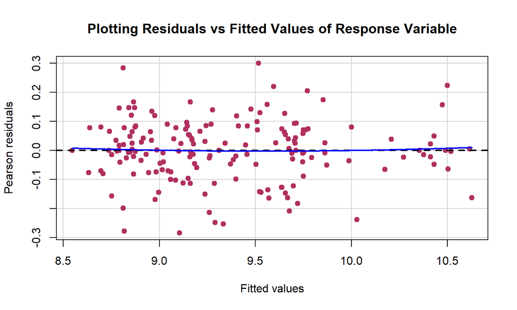

- The residuals are randomly scattered.

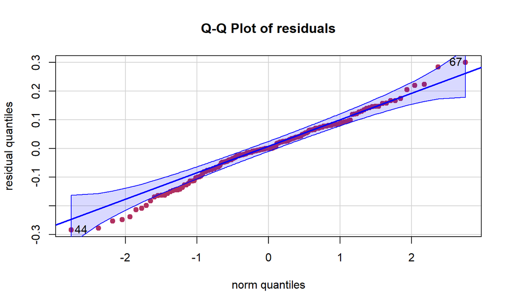

```
## 67 44
## 55 36
```

- The residual quantiles does not coincide with actual normal quantiles.

## Model-3: Removing all Insignificant and Correlated Predictors

- Here, we want to fit a model removing the correlated and insignificant predictors(obtained from Model-2).
- Here 10 out of 12 predictors are significant.
- The siginificant predictors are “curbweight”, “CarName_bmw”, “CarName_dodge”, “CarName_maxda”, “CarName_mitsubishi”, “CarName_toyota”, “aspiration_turbo”, “carbody_wagon”, “enginelocation_rear”, “fuelsystem_mpfi”.
- Multiple R-square = 0.9162.

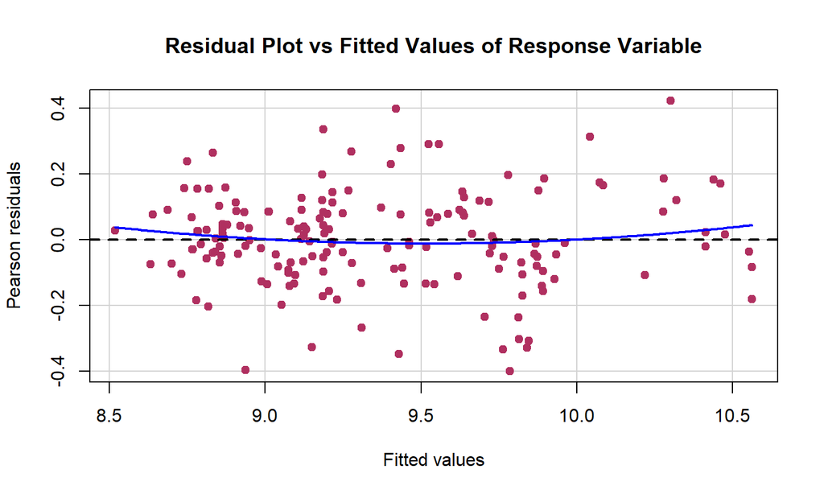

- The residuals are randomly scattered.

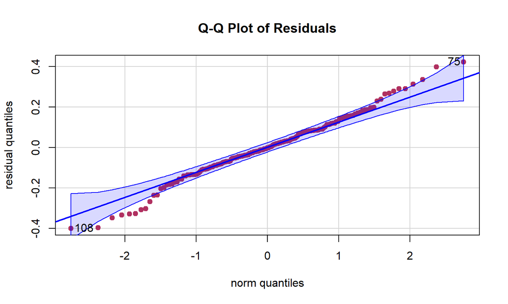

```
##  75 108
##  62  90
```

- The residual quantiles does not coincide with actual normal quantiles at the two ends,but it coincides good in the middle portion.

```
##
##  Shapiro-Wilk normality test
##
## data:  resid(lm(y ~ ., train4))
## W = 0.9872, p-value = 0.1218
```

- H0 is accepted and we conclude that residuals follows normal distribution.

## Model-4: Lasso Regression

- Here, we use Lasso as variable selection method.

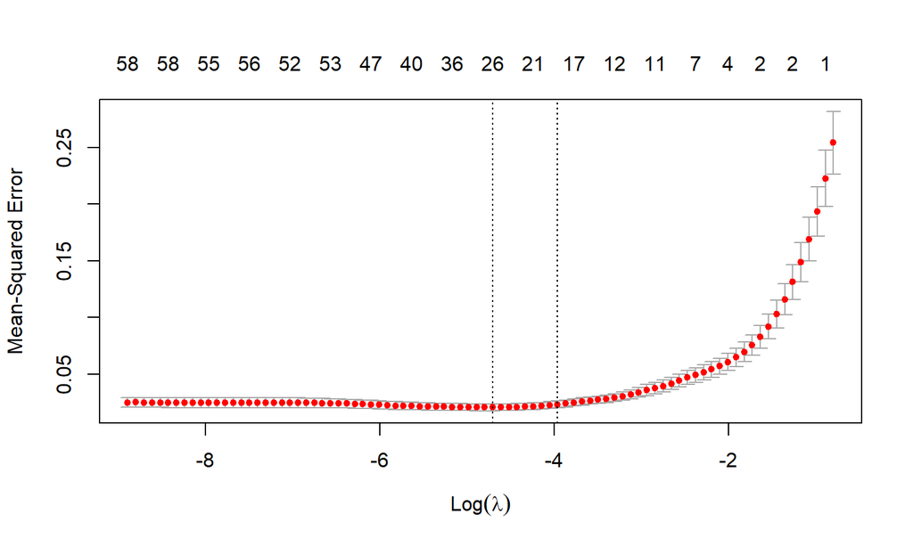

- Now, we want to get the value of lambda.

```
##  lambda.min  lambda.1se
## 0.009039115 0.019026471
```

- We will collect those variable for which the value of coefficient are non zero which is provided by lasso model by taking lambda = 0.019.

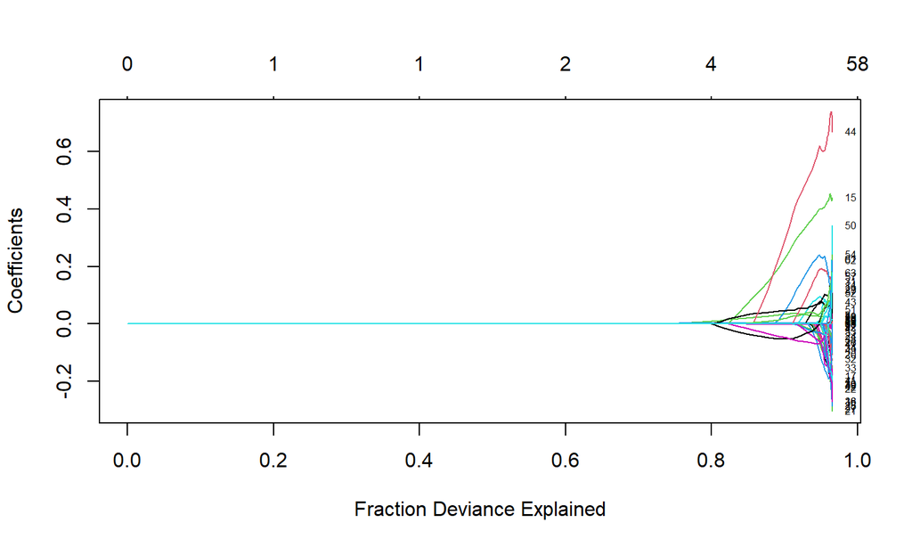

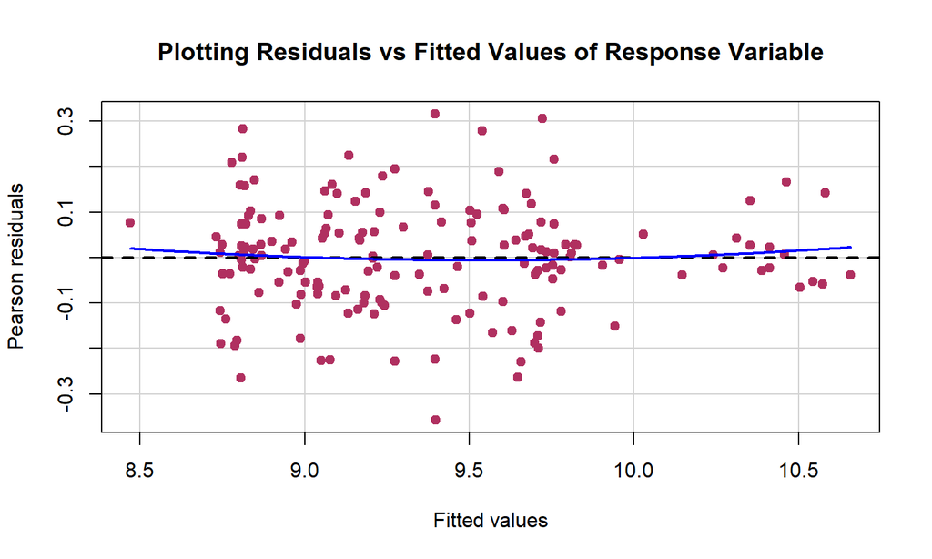

- The residuals are randomly scattered.

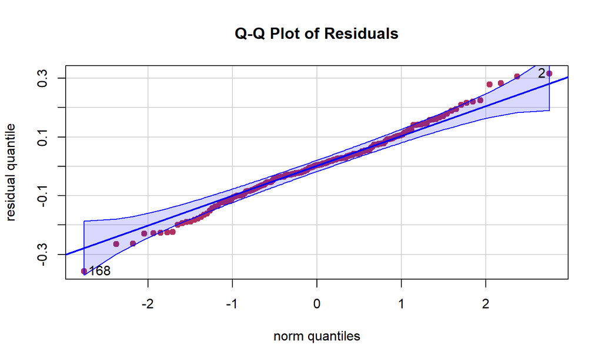

```
## 168   2
## 140   2
```

- The residual quantiles coincides more or less with actual normal quantiles.

```
##
##  Shapiro-Wilk normality test
##
## data:  resid(s5)
## W = 0.99239, p-value = 0.5087
```

- H0 is accepted and we conclude that residuals follows normal distribution.

## Model Comparison

- For Model-3, PRESS = 4.011418.
- For Model-4, PRESS = 2.859928.
- Hence, we can see that w.r.t PRESS, Model-4 is better than Model-3.

## Prediction by Multiple Linear Regression

| Actual log(price) | Fitted log(price) | Actual Price | Fitted Price |
| --- | --- | --- | --- |
| 9.781885 | 9.653845 | 17710.0 | 15581 |
| 9.957265 | 10.002656 | 21105.0 | 22085 |
| 10.333970 | 10.348291 | 30760.0 | 31203 |
| 8.747511 | 8.806175 | 6295.0 | 6675 |
| 8.760453 | 8.699392 | 6377.0 | 5999 |
| 9.469932 | 9.455792 | 12964.0 | 12781 |
| 8.894944 | 8.907264 | 7295.0 | 7385 |
| 9.087608 | 9.125794 | 8845.0 | 9189 |
| 9.095659 | 8.806175 | 8916.5 | 6675 |
| 8.823942 | 8.829218 | 6795.0 | 6830 |
| 9.657907 | 9.398150 | 15645.0 | 12066 |
| 9.286838 | 9.229113 | 10795.0 | 10189 |
| 10.148471 | 10.087345 | 25552.0 | 24036 |
| 8.592115 | 8.719734 | 5389.0 | 6122 |
| 8.730529 | 8.739060 | 6189.0 | 6242 |
| 9.047704 | 9.024487 | 8499.0 | 8303 |
| 8.902320 | 8.739673 | 7349.0 | 6245 |
| 9.099297 | 9.140660 | 8949.0 | 9326 |
| 9.487972 | 9.850975 | 13200.0 | 18976 |
| 9.722865 | 9.803643 | 16695.0 | 18099 |
| 8.937087 | 8.933887 | 7609.0 | 7584 |
| 9.999616 | 9.604788 | 22018.0 | 14835 |
| 10.519430 | 10.445103 | 37028.0 | 34375 |
| 9.649240 | 9.589922 | 15510.0 | 14616 |
| 9.328923 | 9.466997 | 11259.0 | 12926 |
| 8.584478 | 8.771023 | 5348.0 | 6444 |
| 8.974365 | 8.986580 | 7898.0 | 7995 |
| 9.133243 | 8.886234 | 9258.0 | 7231 |
| 9.209240 | 9.318400 | 9989.0 | 11141 |
| 9.296335 | 9.216568 | 10898.0 | 10062 |
| 8.984067 | 9.181850 | 7975.0 | 9719 |
| 9.535679 | 9.391616 | 13845.0 | 11987 |
| 9.849559 | 9.769915 | 18950.0 | 17499 |
| 10.019936 | 9.865841 | 22470.0 | 19261 |

## Prediction by Lasso

| Actual log(price) | Fitted log(price) | Actual Price | Fitted Price |
| --- | --- | --- | --- |
| 9.781885 | 9.853111 | 17710.0 | 19017 |
| 9.957265 | 9.979904 | 21105.0 | 21588 |
| 10.333970 | 10.376823 | 30760.0 | 32106 |
| 8.747511 | 8.744945 | 6295.0 | 6278 |
| 8.760453 | 8.732237 | 6377.0 | 6199 |
| 9.469932 | 9.454448 | 12964.0 | 12764 |
| 8.894944 | 8.944721 | 7295.0 | 7667 |
| 9.087608 | 9.120969 | 8845.0 | 9145 |
| 9.095659 | 8.797501 | 8916.5 | 6617 |
| 8.823942 | 8.917391 | 6795.0 | 7460 |
| 9.657907 | 9.561431 | 15645.0 | 14206 |
| 9.286838 | 9.336438 | 10795.0 | 11343 |
| 10.148471 | 10.249453 | 25552.0 | 28267 |
| 8.592115 | 8.773595 | 5389.0 | 6461 |
| 8.730529 | 8.774342 | 6189.0 | 6466 |
| 9.047704 | 9.008265 | 8499.0 | 8170 |
| 8.902320 | 8.772194 | 7349.0 | 6452 |
| 9.099297 | 9.027951 | 8949.0 | 8332 |
| 9.487972 | 9.693478 | 13200.0 | 16211 |
| 9.722865 | 9.677590 | 16695.0 | 15956 |
| 8.937087 | 8.925754 | 7609.0 | 7523 |
| 9.999616 | 9.605526 | 22018.0 | 14846 |
| 10.519430 | 10.431855 | 37028.0 | 33923 |
| 9.649240 | 9.599092 | 15510.0 | 14751 |
| 9.328923 | 9.321663 | 11259.0 | 11177 |
| 8.584478 | 8.726018 | 5348.0 | 6161 |
| 8.974365 | 8.987968 | 7898.0 | 8006 |
| 9.133243 | 8.871017 | 9258.0 | 7122 |
| 9.209240 | 9.350936 | 9989.0 | 11509 |
| 9.296335 | 9.218668 | 10898.0 | 10083 |
| 8.984067 | 9.132058 | 7975.0 | 9247 |
| 9.535679 | 9.239211 | 13845.0 | 10292 |
| 9.849559 | 9.761232 | 18950.0 | 17347 |
| 10.019936 | 9.738736 | 22470.0 | 16962 |

## Comparison of Prediction

[figure not shown]